# Introdução a Disciplina (ADP343)

Análise de Dados Financeiros e Econômicos com o R

Marcelo S. Perlin

EA-UFRGS

19/08/2026

# Sobre o professor

## Marcelo S. Perlin (ou prof Perlin)

> Professor Associado na EA/UFRGS, orientador de mestrado e doutorado. Com mais de 16 anos de carreira em análise de dados voltada a ciência, finanças quantitativas e consultoria para empresas.
- Apaixonado por análise de dados, programação e investimentos.
- Programador e consultor em **R** e **Python**.
- Autor de diversos pacotes de código aberto no R: `yfR`, `GetTDData`, `GetBCBData`, etc.
- Autor de livros sobre análise de dados e investimentos (detalhes a seguir)
- Contato
  - Email: marceloperlin@gmail.com
  - Site: https://www.msperlin.com/

## Livros Escritos

[figure not shown]

[figure not shown]

[figure not shown]

[figure not shown]

[figure not shown]

[figure not shown]

Links disponíveis na [página pessoal](https://msperlin.com/publication/#5)

# Sobre a disciplina

## Descrição

- Curso de **programação** e análise de dados com o **R**, voltado a pesquisa empírica com dados financeiros e econômicos
  - Baseado no livro *Análise de Dados Financeiros e Econômicos com o R (adfeR)*;
- **Objetivo**: Preparar alunos para a produção de suas dissertações e teses;
- Estilo de *workshop*: teremos programação em todas as aulas, com **problemas reais** a serem resolvidos;
- Ao final do curso, alunos devem estar aptos a conduzir, **de forma autônoma**, uma pesquisa científica usando o R.

## Livro Referência

[figure not shown]

Disponível em:

- [Amazon (pt-br)](https://www.amazon.com.br/gp/product/B08WNC27ZY/)
- [Amazon (en-us)](https://www.amazon.com.br/gp/product/B084LSNXMN)
- [Versão online (pt-br)](https://www.msperlin.com/books/adfeR/) | [Versão online (en-us)](https://www.msperlin.com/books/afedr/)
- [Vídeos no Youtube](https://www.youtube.com/watch?v=CFd8O4f5bm4&list=PLO0YoYcxF6WFR1i45IRTnJ7-Xosrsx-Hl)
- Pdf com obra completa está disponível no GDrive.

## Avaliação do Curso

Avaliação da Disciplina

| Evento | Notas |
| --- | --- |
| Prova I | 20% |
| Prova II | 20% |
| Trabalho Final | 40% |
| Atividades em Aula | 20% |
| Atividade recuperação (nota substitutiva) | 20% |

## Plano de Aula

[Link Gsheets](https://docs.google.com/spreadsheets/d/1NkBdP-BEXJ_OOofRcy1eD-NgTiEE6x2C9mV_hl33-Ys/edit?usp=sharing)

## Atividades EAD

- A cada 2-3 aulas teremos atividades a distância, as quais contarão para nota final;
- A resolução deve ser entregue individualmente, mas trabalho em grupo é incentivado, desde que auxilie na produção de conhecimento;

## Trabalho final da Disciplina

- Ciclo completo de pesquisa aplicada sobre dados de interesse do aluno, com nível aceitável de **análise de dados e programação em R**;
- Fases:
  - Descrição do problema, análise exploratória dos dados (entrega 1)
  - Pesquisa estatística e modelagem (entrega 2)
  - Conclusão e apresentação (entrega 3)

## Uso de AI (chat gpt/Gemini/Claude)

> O atalho técnico somente se justifica com entendimento do conteúdo.

> O uso de AI **não substitui** a necessidade de **entendimento do conteúdo** e **capacidade de programação**;
- Honestidade acima de tudo;
  - O uso de AI é **permitido**, desde que seja **declarado** e **justificado**;
- O AI não vai lhe ajudar a absorver o conteúdo, mas pode ajudar a **automatizar tarefas repetitivas** e **gerar ideias**;

## Formato de aula

[figure not shown]

## O que preciso de vocês (alunos)

- Confirmar recebimento de email de teste de comunicação (não precisa dar reply ao email)
- Teste do Moodle e do GDrive
- Alguma dúvida??

# Pesquisa em Finanças

## Introdução

> Research is a systematic inquiry to describe, explain, predict and control the observed phenomenon. (Babbie 2015)
- Na prática, pesquisa aplicada é um jogo de argumentação baseada em informação incompleta e análise de dados.
- Carreiras em Finanças
  - Bancos e fundos (analista buy/sell side, traders quantitativos)
  - Bancos centrais, agências de regulação e centros de pesquisa
  - Analista/engenheiro de dados e ML (modelos preditivos)
  - Pesquisa e docência acadêmica

## Áreas de Finanças

No Brasil:

- Derivativos e Risco
- Econometria e Métodos Numéricos em Finanças
- Finanças Corporativas
- Investimentos

No mundo:

- Corporate Governance
- Asset Pricing
- Portfolio Management and Asset Allocation
- Risk Management
- Financial Crisis
- Management Compensation
- Investments - Behavioural Issues
- Market Efficiency and Anomalies
- Venture Capital
- Market Microstructure
- Credit Risk
- and more..

## Ciclo de Vida de um Artigo Científico

1. Pesquisa e Desenvolvimento (código, escrita e muito estudo) (3 - 6 meses)
2. [Opcional] Congressos (EBFIN, ENAMPAD, EFMA, ..)
3. Revisão do artigo
4. Submissão para Periódicos:
- Desk-reject (o editor entende que não é um bom “fit” para o periódico)
- Revisão #1 -> Revisão #2 -> Revisão #3..#K
1. Publicação e Churrasco!
2. Siga para etapa 1 e repita

## Dicas para a sua produção científica

- Artigos = vitrine acadêmica
- Escolha um tópico que alinhe com a sua carreira profissional
- Todo trabalho deve ter um claro lugar na literatura
  - o peso da inovação muda de acordo com título acadêmico: pouco peso para o mestrado, alto peso para doutorado
- Simplique - método **KISS**
- um bom **acadêmico** deve saber **falar**, **escrever** e **programar/analisar dados**. Escolha dois!
- Aproveite! Passa rápido.
- **A escolha do software correto para a pesquisa é fundamental!**

## Softwares para pesquisa científica

- Escrita e Edição de texto
  - LLMs (ChatGPT & Gemini) !?
  - Word (MSFT)/Writer (Libreoffice)/Google Docs (Mathtype + Zotero)
  - **Latex** (Miktex/Texlive + texstudio, [Overleaf](https://www.overleaf.com/project))
- Tabelas
  - Excel/Calc/Google Sheets
  - Latex, com exportação via código
- Referências
  - Endnote (Word), **Bibtex** (Latex), **Zotero** (Word e Latex)
- Manipulação de dados e teste de hipóteses
  - **R**, Python, Stata, SPSS, SAS, Matlab, entre muitos outros

## Software de pesquisa

> A ciência promove **colaboração** e **reproducibilidade**

Um software deve ser escolhido baseado em:

- A capacidade de resolver o problema
- A facilidade de compartilhar procedimentos (colaboração e reproducibilidade)
- Na prática, programas de pesquisa são escolhidos com base em:
  - O que o grupo de pesquisa/orientador usa;
  - Quão fácil é para você usar;
  - Quão bonito é a interface gráfica;
  - O orçamento ($);

> Aprender a utilizar os programas corretos não é fácil, mas existem fortes benefícios no longo prazo
- Automatizar procedimentos em dados;
- Trabalhar inteligente, e não intensamente (*work smarter, not harder*)
- Reutilizar (e abusar) de códigos antigos ou de outras pessoas.

# Sobre o R

## O que é o R

> Ross Ihaka and Robert Gentleman. R: A language for data analysis and graphics. Journal of Computational and Graphical Statistics, 5(3):299–314, 1996. (Ihaka and Gentleman 1996)

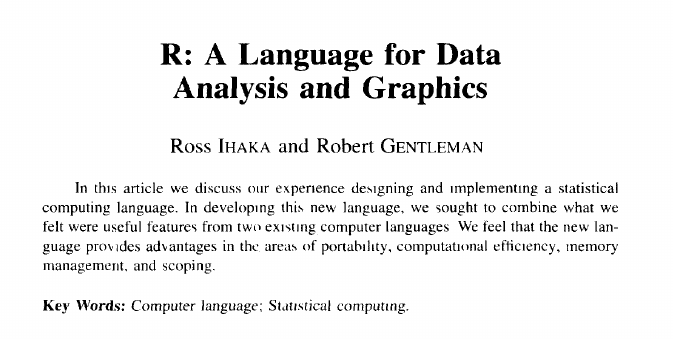

## Cronologia

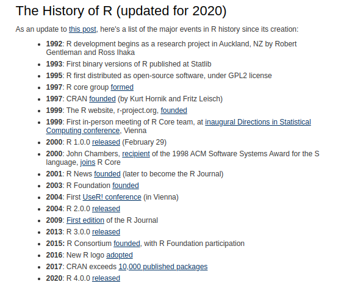

[Cronologia da criação do R](https://blog.revolutionanalytics.com/2017/10/updated-history-of-r.html)

## Sobre o R

**Definição**

O R é uma linguagem de programação voltada para a resolução de problemas estatísticos e para a visualização gráfica de dados.

**Autores**

Ross Ihaka e Robert Gentleman (*The University of Auckland*)

**Funcionalidade**

R é sinônimo de programação voltada à análise de dados

**Custo**

**O R é totalmente livre** e disponível em vários sistemas operacionais.

## Por que Escolher o R

- R é uma plataforma madura, estável, continuamente suportada e intensamente utilizada na indústria.
- Aprender a linguagem do R é fácil.
- A interface do R e RStudio torna o uso da ferramenta bastante produtivo.
- Os pacotes do R permitem as mais diversas funcionalidades.
- O R tem compatibilidade com diferentes linguagens e sistemas operacionais.
- O R é totalmente gratuito!

## R VS Python

| Característica | R | Python |
| --- | --- | --- |
| **Ponto Forte Principal** | Análise Estatística e Visualização | Versatilidade e Machine Learning |
| **Curva de Aprendizagem** | Moderada, especialmente para não-programadores | Baixa, sintaxe clara e intuitiva |
| **Principais Bibliotecas** | `ggplot2`, `dplyr`, `tidyverse` | `Pandas`, `NumPy`, `Scikit-learn` |
| **Uso Ideal** | Pesquisa, estatística, análise exploratória | Projetos de ponta a ponta, machine learning, integração |
| **Comunidade** | Forte na academia e pesquisa | Ampla e diversa, forte na indústria de tecnologia |

## Usos do R

- Importação, exportação, tratamento e armazenamento de dados financeiros e econômicos com base em arquivos locais ou da internet;
- Criação de rotinas para o cálculo e a administração do risco de uma carteira de investimento;
- Desenvolvimento de rotinas para a administração e execução de ordens financeiras no mercado de capitais;
- Criação de ferramentas para controle, avaliação e divulgação de índices econômicos sobre um país ou região;
- Execução de diversas possibilidades de pesquisa empírica através da estimação de modelos econométricos e testes de hipóteses;
- Criação de *websites* dinâmicos com o pacote `Shiny`, possibilitando que qualquer pessoa no mundo utilize uma ferramenta criada por você;
- Organização de um processo automatizado de criação e divulgação de relatórios técnicos com o pacote `knitr` e a tecnologia *RMarkdown*.

## Downloads pelo mundo e Brasil

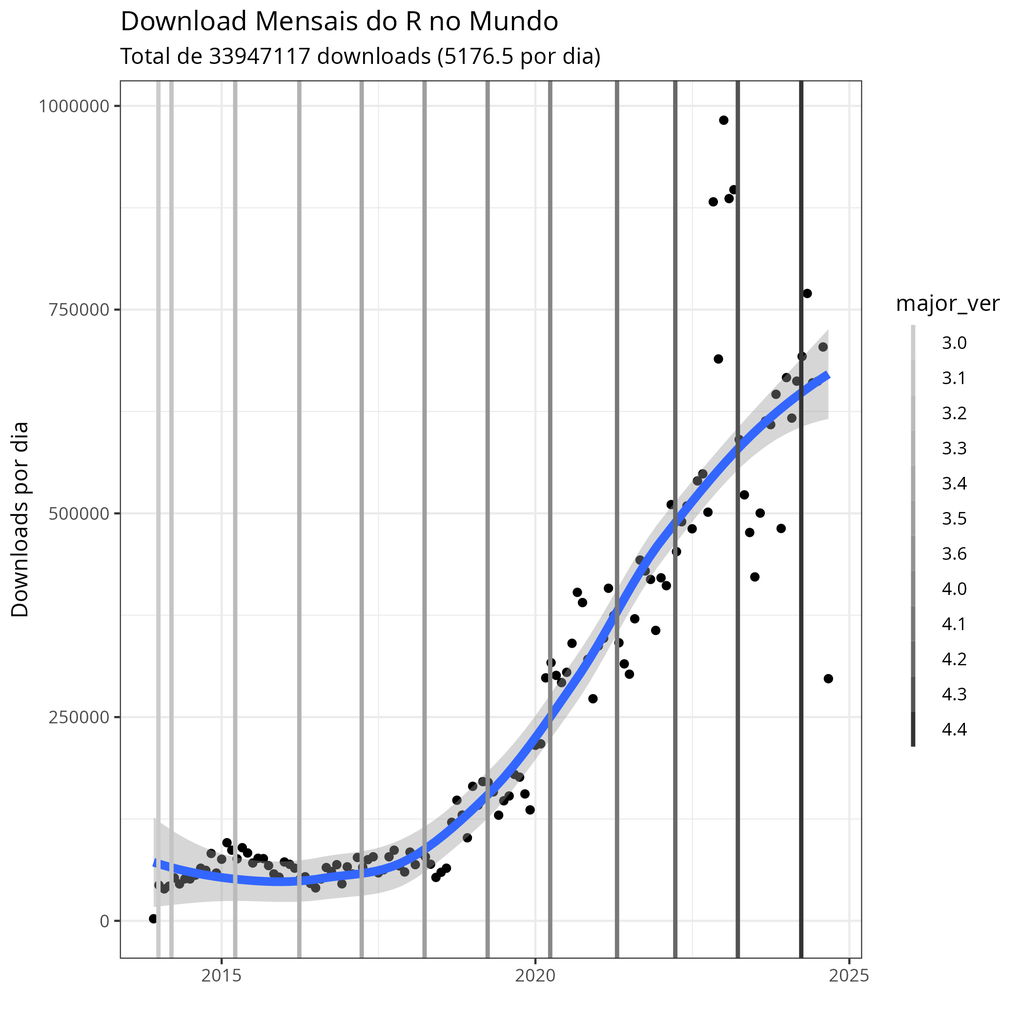

Downloads no Mundo

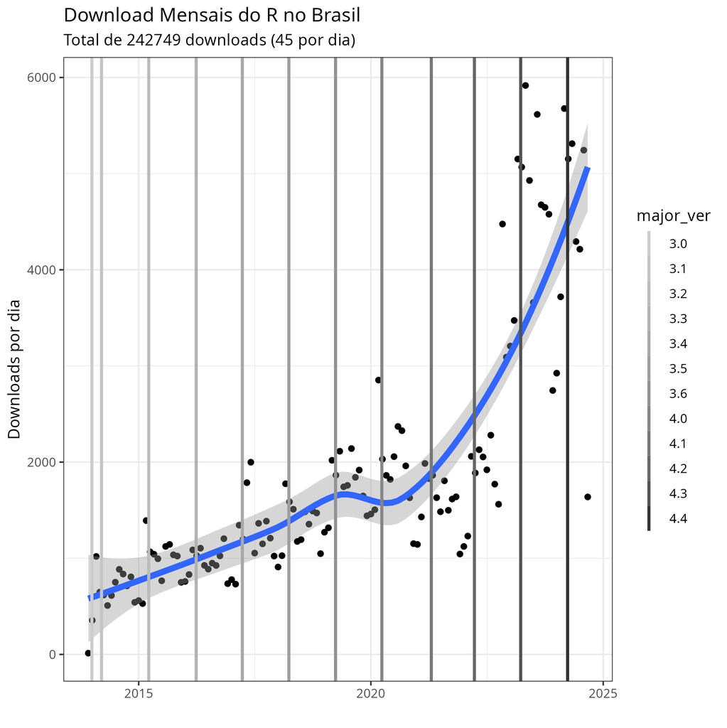

Downloads no Brasil

## Número de pacotes no CRAN

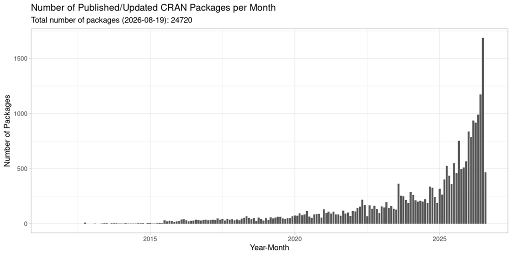

## Instalando R e o RStudio

**R**

[Instalador do R (maior versão encontrada)](https://cran.r-project.org/bin/windows/base/)

**Rtools (apenas usuários do windows)**

[Instalador RTools (maior versão encontrada)](https://cran.r-project.org/bin/windows/Rtools/)

**RStudio**

https://www.rstudio.com/

**Positron**

https://www.appsilon.com/post/introducing-positron

Também recomendo a instalação do tinytex para compilação de relatórios em pdf Latex:

```r
# execute no prompt do R
install.packages('tinytex')
tinytex::install_tinytex()
```

## Referências

Babbie, Earl R. 2015. *The Practice of Social Research*. Nelson Education.

Ihaka, Ross, and Robert Gentleman. 1996. “R: A Language for Data Analysis and Graphics.” *Journal of Computational and Graphical Statistics* 5 (3): 299–314.

Perlin, Marcelo Scherer, and André Alves Portela Santos. 2015. “Os Pesquisadores, as Publicações e Os Periódicos Da área de Finanças No Brasil: Uma análise Com Base Em Currı́culos Da Plataforma Lattes.” *Revista Brasileira de Finanças. Rio de Janeiro. Vol. 13, n. 2 (Abr. 2015), p. 162-199*.